# Repeating Steps with Data2

# Loops can be “nested” on loop inside the other

Example: Calculate NPV for

- a range of different interest rates and
- a range of damages
- that may be incurred 10 years in the future

Steps

- define inputs (interest rates, damages)
- define output (NPV)
- write the function
- create a data structure to store results where we vary both interest rates and damages
- use nested for loops to fill in the data structure

Try it first…

```
## function (value, time, discount)
## {
##     result = value/(1 + discount)^time
##     return(result)
## }
```

```
## [1] 16.39089
```

```
##         V1       V2       V3       V4       V5       V6       V7
## 1 22.63217 21.54168 20.50871 19.52996 18.60235 17.72297 16.88910
## 2 29.87447 28.43502 27.07149 25.77955 24.55510 23.39432 22.29362
## 3 82.38111 78.41172 74.65170 71.08905 67.71255 64.51161 61.47634
## 4 21.72689 20.68001 19.68836 18.74876 17.85825 17.01405 16.21354
```

```
##        0.01    0.015     0.02    0.025     0.03    0.035     0.04
## 25 22.63217 21.54168 20.50871 19.52996 18.60235 17.72297 16.88910
## 33 29.87447 28.43502 27.07149 25.77955 24.55510 23.39432 22.29362
## 91 82.38111 78.41172 74.65170 71.08905 67.71255 64.51161 61.47634
## 24 21.72689 20.68001 19.68836 18.74876 17.85825 17.01405 16.21354
```

```
## # A tibble: 6 x 2
##   dis     npv
##   <chr> <dbl>
## 1 0.01   22.6
## 2 0.015  21.5
## 3 0.02   20.5
## 4 0.025  19.5
## 5 0.03   18.6
## 6 0.035  17.7
```

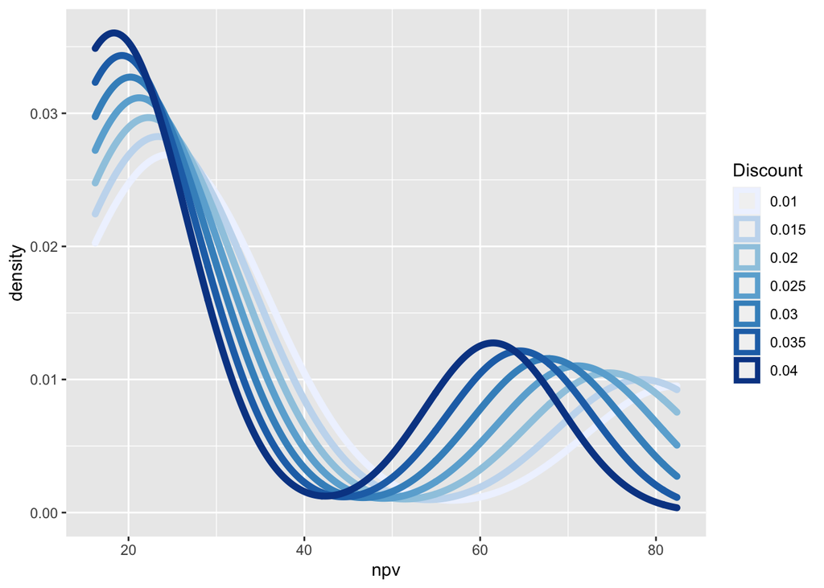

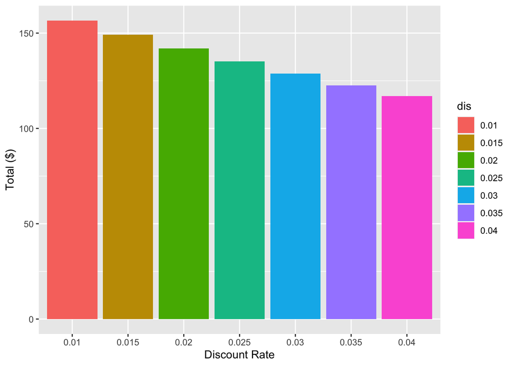

```
## * NA -> ...1
## * NA -> ...2
## * NA -> ...3
## * NA -> ...4
```

```
## # A tibble: 6 x 2
##   dis     npv
##   <chr> <dbl>
## 1 ...1   22.6
## 2 ...2   29.9
## 3 ...3   82.4
## 4 ...4   21.7
## 5 ...1   21.5
## 6 ...2   28.4
```

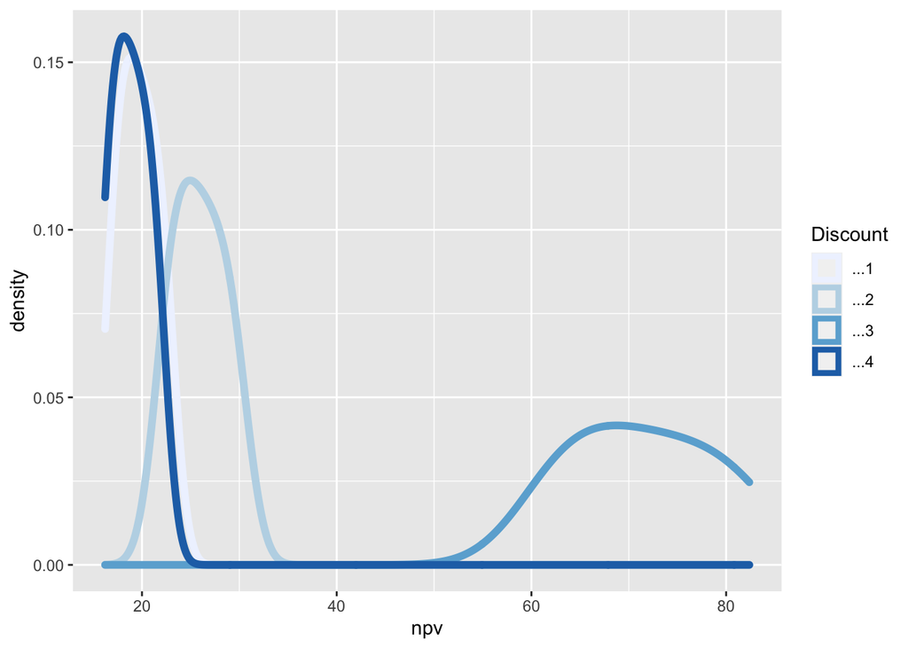

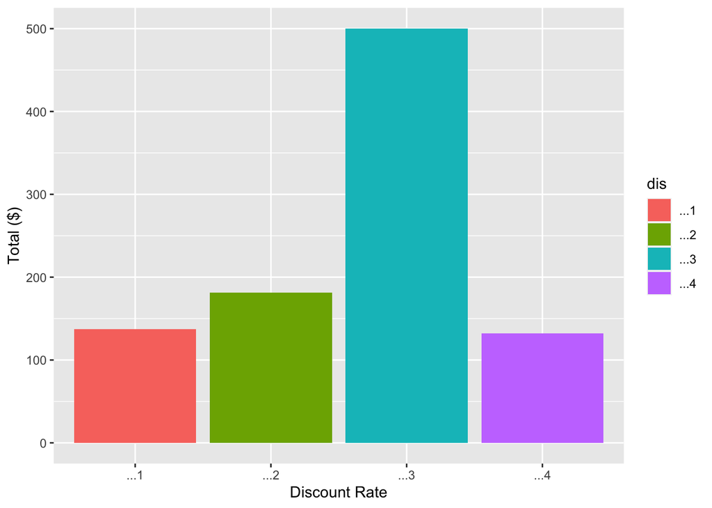

# Some other types of loops

- while useful for repeating until a condition is met

Example if a metal toxin in a lake increases by 1% per year, how many years will it take for the metal level to be greater than 30 units, if toxin is current at 5 units

```r
# accumulate pollutant until a threshold - how many years does it take

# initial conditions
yr=1
pollutant_level = 5

# loop
while ((pollutant_level < 30) &&(yr < 1000))  {
  # increase pollutant
pollutant_level = pollutant_level + 0.01* pollutant_level
# keep track of time
yr = yr + 1
}

pollutant_level
```

```
## [1] 30.2788
```

```r
yr
```

```
## [1] 182
```

```r
# while loop dangers
# what if it doesn't end....

# see below - I left it commented out -because it will run for ever :)
# you can use controlC to stop

#while ((pollutant_level < 30))  {
  # increase pollutant
#pollutant_level = pollutant_level - 0.01* pollutant_level
#}
```

Another KEY concept is flow control In your function you do different things depending on a conditions

CLASSIC example is

IF then ELSE

If you have multiple conditions we can use case_when Here’s a silly simple example of how it works

```r
# if x is 1, return A, if x is 2, return, B, if x is 3, return, C

x=1
case_when(x ==1 ~ "A", x==2 ~ "B", x==3 ~ "C")
```

```
## [1] "A"
```

```r
x = c(1,2,1,3)
case_when(x ==1 ~ "A", x==2 ~ "B", x==3 ~ "C")
```

```
## [1] "A" "B" "A" "C"
```

# A more interesting example

Lets imagine that we are monitoring pollution in a lake, and we want to write a function that will let us know (flag) a nutrient pollution as high, medium or low

Risk is high if water temperature is greater than a threshold for more than 5 days, and mean nutrient concentration is greater than a high threshold

Risk is medium if water temperature is greater than a threshold for more than 5 days and mean nutrient concentration is greater than a medium threshold

Inputs:  
nutrient concentration for at least 5 days temperature for at least 5 days thresholds for temperature and nutrient (with default values)

Output: Pollution Risk as “low”, “med” or “high”

Take a look at classify_lake * example of while * example of flow control with if..else and case_when

```r
source("R/classify_lake.R")

# generate some data to try the function
temperature = runif(min=4, max=35, n=30)
nutrient = runif(min=5, max=40, n=30)

# try it
classify_lake(temperature=temperature, nutrient=nutrient)
```

```
## [1] "high"
```

```r
# lets pick some numbers we know whould give us a low value
nutrient = runif(min=0, max=5, n=30)
classify_lake(temperature=temperature, nutrient=nutrient)
```

```
## [1] "low"
```

```r
# now try high
# use repeat to generate the same value multiple times
nutrient = rep(50, times=30)
temperature = rep(25, times=30)
classify_lake(temperature=temperature, nutrient=nutrient)
```

```
## [1] "high"
```